# TALKIEN - crossTALK bIpartitE Network -

You can plot customized networks, obtain network parameters and perform enrichment analysis.

### INPUT

User is required to input two list of genes/proteins. Each of them belongs to one of the two entities the user in interested in. To decipher the molecular crosstalk between them, TALKIEN only uses secreted and membrane receptors proteins. The hypothesis behind is that cellular communication could be partially explained by physical interactions between receptor proteins and their specific ligands. Specifically in paracrine signalling, receptors are activated by ligands proteins secreted by another cell. However, TALKIEN also allow users to visualize pathways downstream receptors in the network (see below):

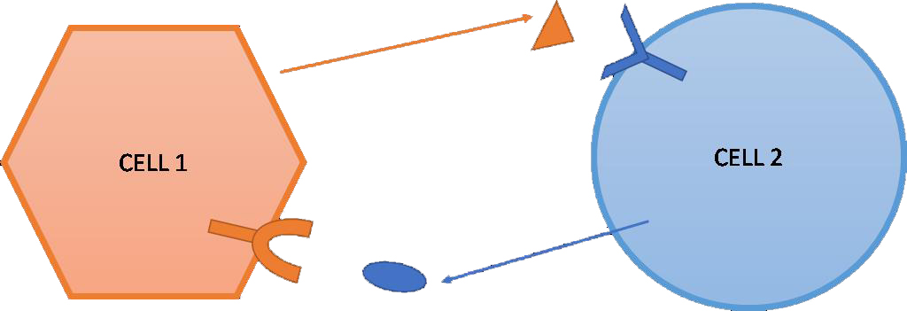

These lists may derive from a variety of experiments and could be measured with diverse transcriptomics (such as RNA-seq, microarray or scRNA-seq) and proteomics approaches (mass spectrometry or protein chips among others). For example, co-culture experiments of cancer cells with/without stromal cells, or cells growing under the stimulation of supernatant media collected from immune cells cultures. Lists from the example came from the following transcriptomic experiment:

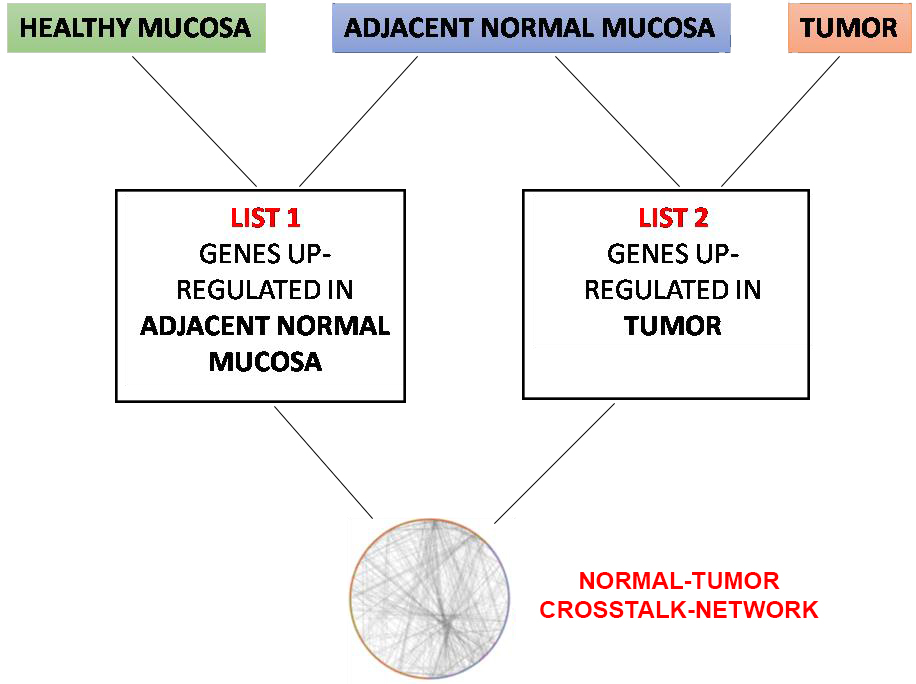

### PLOT NETWORKS

The basic elements of the networks are nodes (Proteins) and edges (interactions between them) that connect nodes within the network. Connections are defined according to a score based on certain evidence of interaction.

**User options.**

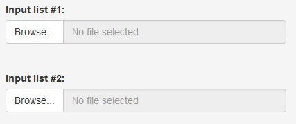

There is a preloaded example with two lists. By selecting “Load example data” option, an example network will be displayed.

2. Choose **Network Database**. By default TALKIEN will combine the two different databases to give wider results.
- STRING
- HIPPIE
- both

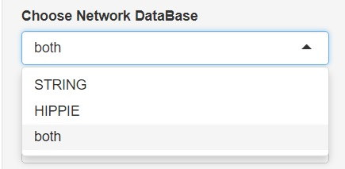

3. Choose **information source**. Nodes have been classified into plasma membrane **Receptors** or extracellular **Secreted** proteins depending on two different sources. Some divergency may be observed between each other.
- Human Protein Atlas
- Uniprot

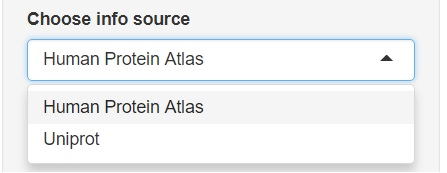

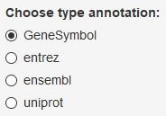

5. Choose **network type**. Users are allowed to compute interactions between lists (the so-called crosstalk) or interactions between and within lists.
- whole –> get interactions from list 1 to list1, from list2 to list2, from list1 to list2, and viceversa
- crosstalk –> get interactions only from list1 to list2 and viceversa

[figure not shown]

6. Select **score threshold**. That is the minimum interaction value to link two proteins. Only protein-protein interaction with scores higher than chosen will be shown in the network. Score threshold is based either on STRING’s combined score or HIPPIE weight score.

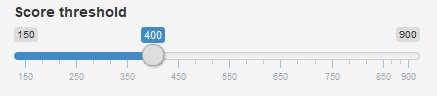

7. Show **downstream interactions**. If selected, all interactions coming from the same list of its receptor parent will be shown. This tree-like structure allow users to have an idea of the possible activation cascades switched on by specific receptors

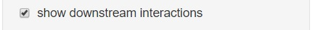

8. Choose **graphical layout**. Users are allowed to choose between 5 different layouts.
- Circular layout.
- Force-directed layout (Fruchterman Reingold algorithm).
- Sphere layout.
- Large Graph layout. Preferred option for large networks. -only for network type **whole**-.
- Bipartite layout. -only for network type **crosstalk**-.

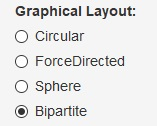

All results could be downloaded by clicking **donwload buttons** on the bottom of the tabs. Network plots could be downloaded first as html objects. Additionally, there is a black button to export the image to a png format once the downloaded html has been opened.

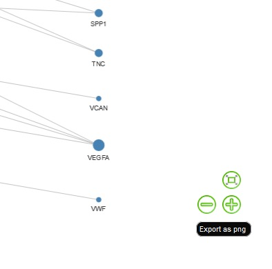

###### MAIN TAB: PLOTS

Network will be displayed and able to be downloaded as an interactive html object. The size of the node is proportional to its degree and the width of the edge is proportional to its interaction score. In **bipartite** mode. There is the option of changing network orientation (UP-DOWN or LEFT-RIGHT) and changing the groups (bipartite network by lists or by location)

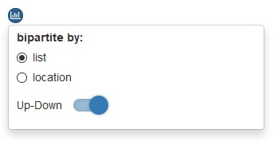

Users can select one node by clicking on it. After selecting one of them, a table with the node’s belonging pathways will be displayed. It shows pathway ID, pathway name and a link to see more in-depth pathway properties on reactome website. Moreover, if **downstream interactions** mode is selected, three additional columns will show pathway’s size, the number of present nodes in network belonging to each of the displayed pathways and a F-test p-value for the enrichment term.

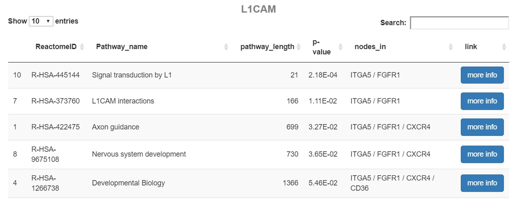

###### NETWORK PARAMETERS TAB

For the plotted network, the network descriptive parameters are displayed: number of nodes and edges, diameter, shortest_Pathway, density, average neighbors, clustering_coefficient and centralization.

For all nodes five different centralization methods are displayed and can be downloaded. For each pair of connected nodes, interaction score, location, list and other annotation IDs are displayed and can be downloaded.

###### ENRICHMENT ANALYSIS TAB

Users are able to perform a functional analysis based on Reactome Pathway Database by selecting this tab

Enrichment analysis results are displayed in two different ways.

- Dotplot with up to 15 top enriched pathways.
- Table summarizing enriched pathways, proteins involved, p-values, enrichment scores, ect.